**Informações sobre a área habitável dos imóveis:**

Da mesma forma que na variável *age*, as faixas de área habitável dos imóveis foram decididas com base na distribuição da variável *sqft_living*. A divisão que tornou o gráfico mais bem distribuído foi de 1000 em 1000 sqft, sendo a última acima de 4000 sqft.

```r
#GRÁFICO DE COLUNAS EMPILHADAS - VISUALIZAÇÃO POR GRUPO
#Criar uma variável que indica a faixa de idade do imóvel
df$faixa_area <- cut(df$sqft_living,
                      breaks = c(-Inf, 1000, 2000, 3000, 4000, Inf),
                      labels = c("< 1000", "1000 - 2000", "2000 - 3000", "3000 - 4000", "> 4000"),
                      include.lowest = TRUE)

#Calcular a proporção de imóveis por grupo e faixa de idade do imóvel
area_tx <- df %>%
  group_by(grupo, faixa_area) %>%
  summarise(count = n()) %>%
  group_by(grupo) %>%
  mutate(proporcao = count / sum(count))

#Adicionar uma coluna para indicar se o rótulo deve ser exibido
area_tx$exibir_rotulo <- area_tx$proporcao >= 0.02

#Criar o gráfico de colunas empilhadas base 100 com rótulos de percentual (1 casa decimal)
plotsq1 <- ggplot(area_tx, aes(x = grupo, y = proporcao, fill = faixa_area)) +
  geom_bar(stat = "identity") +
  geom_text(aes(label = ifelse(exibir_rotulo, scales::percent(proporcao, accuracy = 0.1), "")),
            position = position_fill(vjust = 0.5), size = 5) +
  labs(title = "Percentual de imóveis por faixa de área hábitavel por grupo",
       x = "Grupo",
       y = NULL)+
  scale_fill_manual(values = paleta)+
  guides(fill = FALSE)+
    theme_minimal()


#GRÁFICO DO PREÇO MÉDIO POR FAIXA DE ÁREA HABITÁVEL
#Calcular a média do preço para cada faixa de idade
media_preco_sqft <- df %>%
  group_by(faixa_area) %>%
  summarise(preco_medio = mean(price, na.rm = TRUE))%>%
  mutate(faixa_area = factor(faixa_area, levels = faixa_area))

#Criar o gráfico de barras horizontais
plotsq2 <- ggplot(media_preco_sqft, aes(x = preco_medio, y = faixa_area, fill = faixa_area)) +
  geom_bar(stat = "identity") +
  geom_text(aes(label = scales::dollar(preco_medio)), hjust = 1.1, size = 5) +
  labs(title = "Preço médio por faixa de área habitável no imóvel",
       x = "Preço médio",
       y = "Faixa de área habitável",
       fill = "Área habitável (sqft)")+
  scale_fill_manual(values = paleta)+
    theme_minimal()
```

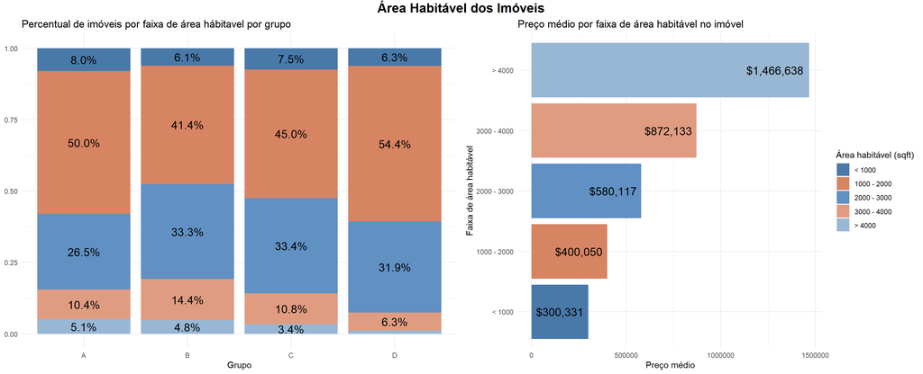

```r
#Unindo os gráficos sobre área habitável dos imóveis
grid.arrange(plotsq1, plotsq2,
            ncol = 2,
            top = textGrob("Área Habitável dos Imóveis", gp = gpar(fontsize = 16, fontface = "bold")))
```

Com os gráficos acima, podemos concluir que a amostra contém imóveis relativamente grandes, sendo que a faixa mais frequente é entre 92 m² e 185 m² (1000 - 2000 sqft), seguida pela faixa entre 185 m² e 278 m² (2000 - 3000 sqft).

**Informações sobre a condição dos imóveis:**

```r
#GRÁFICO DE COLUNAS EMPILHADAS - VISUALIZAÇÃO POR GRUPO
#Calculando a proporção de imóveis por grupo e condição
cond_tx <- df %>%
  group_by(grupo, condition) %>%
  summarise(count = n()) %>%
  group_by(grupo) %>%
  mutate(proporcao = count / sum(count))

#Coluna para indicar se o rótulo deve ser exibido (ocultando para uma visualização mais limpa)
cond_tx$exibir_rotulo <- cond_tx$proporcao >= 0.01

#Criando o gráfico de colunas empilhadas base 100 com rótulos de percentual (1 casa decimal)
plotcd1 <- ggplot(cond_tx, aes(x = grupo, y = proporcao, fill = as.factor(condition))) +
  geom_bar(stat = "identity") +
   geom_text(aes(label = ifelse(exibir_rotulo, scales::percent(proporcao, accuracy = 0.1), "")),
            position = position_fill(vjust = 0.5), size = 5) +
  labs(title = "Percentual de imóveis por nota de condição grupo",
       x = "Grupo",
       y = NULL)+
  guides(fill = FALSE)+
  scale_fill_manual(values = paleta)+
    theme_minimal()

#GRÁFICO DO PREÇO MÉDIO POR NÚMERO DE ANDARES
#Calcular a média do preço para cada nota de condição
media_preco_cond <- df %>%
  group_by(condition) %>%
  summarise(preco_medio = mean(price))%>%
  mutate(condition = factor(condition, levels = condition))

#Criar o gráfico de barras horizontais
plotcd2 <- ggplot(media_preco_cond, aes(x = preco_medio, y = condition, fill = condition)) +
  geom_bar(stat = "identity") +
  geom_text(aes(label = scales::dollar(preco_medio)), hjust = 1.1, size = 5) +
  labs(title = "Preço médio por nota de condição dos imóveis",
       x = "Preço médio",
       y = "Nota de condição",
       fill = "Nota de condição")+
  scale_fill_manual(values = paleta)+
    theme_minimal()
```

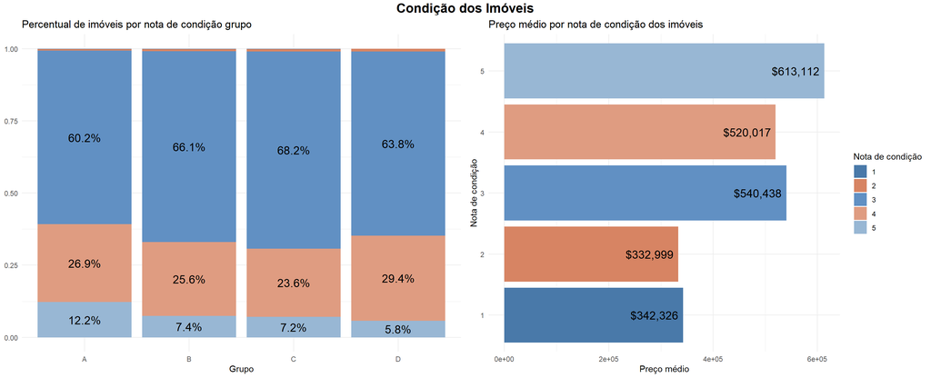

```r
#Unindo os gráficos sobre condição
grid.arrange(plotcd1, plotcd2,
            ncol = 2,
            top = textGrob("Condição dos Imóveis", gp = gpar(fontsize = 16, fontface = "bold")))
```

**Informações sobre a nota geral dos imóveis:**

As faixas de nota dos imóveis foram decididas com base na distribuição da variável *grade*. A divisão que tornou o gráfico mais bem distribuído foi de 2 em 2 sqft, sendo a última acima de 10 (nas estatísticas descritivas, verificou-se que o vaor máximo é 13).

```r
#GRÁFICO DE COLUNAS EMPILHADAS - VISUALIZAÇÃO POR GRUPO
#Criar uma variável que indica a faixa de idade do imóvel
df$faixa_grade <- cut(df$grade,
                      breaks = c(-Inf, 2, 4, 6, 8, 10, Inf),
                      labels = c("< 2", "2 - 4", "4 - 6", "6 - 8", "8 - 10", "> 10"),
                      include.lowest = TRUE)

#Calculando a proporção de imóveis por grupo e categoria de nota
grade_tx <- df %>%
  group_by(grupo, faixa_grade) %>%
  summarise(count = n()) %>%
  group_by(grupo) %>%
  mutate(proporcao = count / sum(count))

#Coluna para indicar se o rótulo deve ser exibido (ocultando para uma visualização mais limpa)
grade_tx$exibir_rotulo <- grade_tx$proporcao >= 0.02

#Criando o gráfico de colunas empilhadas base 100 com rótulos de percentual (1 casa decimal)
plotgd1 <- ggplot(grade_tx, aes(x = grupo, y = proporcao, fill = faixa_grade)) +
  geom_bar(stat = "identity") +
  geom_text(aes(label = ifelse(exibir_rotulo, scales::percent(proporcao, accuracy = 0.1), "")),
            position = position_fill(vjust = 0.5), size = 5) +
  labs(title = "Percentual de imóveis por nota geral",
       x = "Grupo",
       y = NULL,
       fill = "Nota geral")+
  guides(fill = FALSE)+
  scale_fill_manual(values = paleta)+
    theme_minimal()

#GRÁFICO DO PREÇO MÉDIO POR CATEGORIA DE NOTA
#Calcular a média do preço para cada categoria de nota
media_preco_grade <- df %>%
  group_by(faixa_grade) %>%
  summarise(preco_medio = mean(price)) %>%
  mutate(faixa_grade = factor(faixa_grade, levels = faixa_grade))

#Criando o gráfico de barras horizontais
plotgd2 <- ggplot(media_preco_grade, aes(x = preco_medio, y = faixa_grade, fill = faixa_grade)) +
  geom_bar(stat = "identity") +
  geom_text(aes(label = scales::dollar(preco_medio)), hjust = 1.1, size = 5) +
  labs(title = "Preço médio por nota geral",
       x = "Preço médio",
       y = "Nota geral",
       fill = "Nota geral")+
  scale_fill_manual(values = paleta)+
    theme_minimal()
```

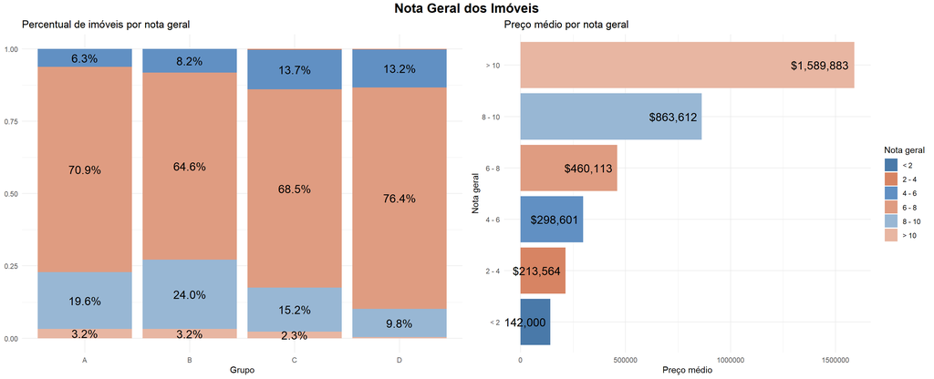

```r
#Unindo os gráficos sobre nota geral
grid.arrange(plotgd1, plotgd2,
            ncol = 2,
            top = textGrob("Nota Geral dos Imóveis", gp = gpar(fontsize = 16, fontface = "bold")))
```

Nos gráficos acima, observamos que a maior parte dos imóveis receberam notas entre 6 e 8, sendo o grupo que possui mais percentual de notas acima de 8 o B.

**Informações sobre o % da área habitábel que é porão:**

```r
#GRÁFICO DE COLUNAS EMPILHADAS - VISUALIZAÇÃO POR GRUPO
#Criar uma variável que indica a faixa de % de porão
df$faixa_bsmt <- cut(df$basement_percent,
                      breaks = c(-Inf, 0.1, 0.3, 0.6, Inf),
                      labels = c("< 10%", "10% - 30%", "30% - 60%", "> 60%"),
                      include.lowest = TRUE)

#Calculando a proporção de imóveis por grupo e faixa de % de porão
bsmt_tx <- df %>%
  group_by(grupo, faixa_bsmt) %>%
  summarise(count = n()) %>%
  group_by(grupo) %>%
  mutate(proporcao = count / sum(count))

#Coluna para indicar se o rótulo deve ser exibido (ocultando para uma visualização mais limpa)
bsmt_tx$exibir_rotulo <- bsmt_tx$proporcao >= 0.02

#Criando o gráfico de colunas empilhadas base 100 com rótulos de percentual (1 casa decimal)
plotbm1 <- ggplot(bsmt_tx, aes(x = grupo, y = proporcao, fill = faixa_bsmt)) +
  geom_bar(stat = "identity") +
  geom_text(aes(label = ifelse(exibir_rotulo, scales::percent(proporcao, accuracy = 0.1), "")),
            position = position_fill(vjust = 0.5), size = 5) +
  labs(title = "Percentual de imóveis por % de porão",
       x = "Grupo",
       y = NULL,
       fill = "% de porão")+
  guides(fill = FALSE)+
  scale_fill_manual(values = paleta)+
    theme_minimal()

#GRÁFICO DO PREÇO MÉDIO POR % DE PORÃO
#Calcular a média do preço para cada faixa de % de porão
media_preco_bsmt <- df %>%
  group_by(faixa_bsmt) %>%
  summarise(preco_medio = mean(price))%>%
  mutate(faixa_bsmt = factor(faixa_bsmt, levels = faixa_bsmt))

#Criando o gráfico de barras horizontais
plotbm2 <- ggplot(media_preco_bsmt, aes(x = preco_medio, y = faixa_bsmt, fill = faixa_bsmt)) +
  geom_bar(stat = "identity") +
  geom_text(aes(label = scales::dollar(preco_medio)), hjust = 1.1, size = 5) +
  labs(title = "Preço médio por % de porão",
       x = "Preço médio",
       y = "% de porão",
       fill = "% de porão")+
  scale_fill_manual(values = paleta)+
    theme_minimal()
```

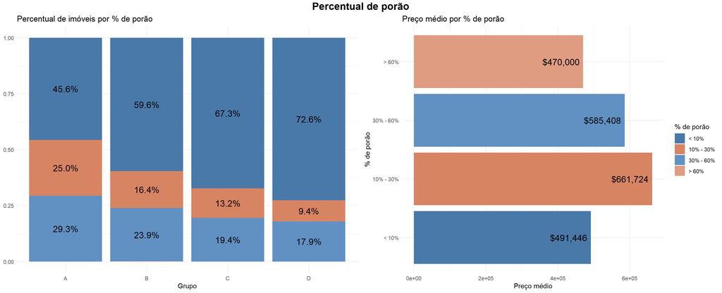

```r
#Unindo os gráficos sobre % de porão
grid.arrange(plotbm1, plotbm2,
            ncol = 2,
            top = textGrob("Percentual de porão", gp = gpar(fontsize = 16, fontface = "bold")))
```

Conclusões da análise exploratória